# Changes on CRAN

The ‘Changes on CRAN’ article from the 2021-1 issue.

Kurt Hornik (

WU Wirtschaftsuniversität Wien, Austria

) , Uwe Ligges (

TU Dortmund, Germany

) , Achim Zeileis (

Universität Innsbruck, Austria

)  
2021-06-01

In the past 6 months, 1290 new packages were added to the CRAN package repository. 116 packages were unarchived and 467 were archived. The following shows the growth of the number of active packages in the CRAN package repository:

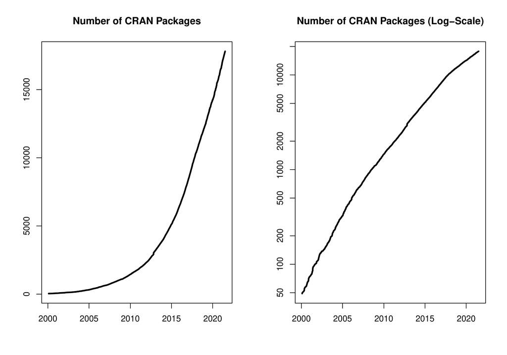

On 2021-06-30, the number of active packages was around 17778.

### 1 CRAN package submissions

Minus some special cases, a summary of the auto-processed and manually triggered actions follows:

|  | archive | inspect | newbies | pending | pretest | publish | recheck | waiting |
| --- | --- | --- | --- | --- | --- | --- | --- | --- |
| auto | 6191 | 5988 | 5585 | 0 | 0 | 7244 | 2429 | 1602 |
| manual | 6586 | 117 | 874 | 855 | 249 | 5467 | 1322 | 335 |

These include the final decisions for the submissions which were

| action | archive | publish |
| --- | --- | --- |
| auto | 5573 (22.5%) | 6131 (24.8%) |
| manual | 6478 (26.2%) | 6544 (26.5%) |

where we only count those as *auto* processed whose publication or rejection happened automatically in all steps.

### 2 CRAN mirror security

Currently, there are 103 official CRAN mirrors, 82 of which provide both secure downloads via `https` *and* use secure mirroring from the CRAN master (via rsync through ssh tunnels). Since the R 3.4.0 release, `chooseCRANmirror()` offers these mirrors in preference to the others which are not fully secured (yet).

### 3 New packages in CRAN task views

**[*Bayesian*](https://CRAN.R-project.org/view=Bayesian)**

[*causact*](https://CRAN.R-project.org/package=causact), [*dina*](https://CRAN.R-project.org/package=dina), [*edina*](https://CRAN.R-project.org/package=edina), [*errum*](https://CRAN.R-project.org/package=errum), [*greta*](https://CRAN.R-project.org/package=greta), [*mcmcensemble*](https://CRAN.R-project.org/package=mcmcensemble), [*rrum*](https://CRAN.R-project.org/package=rrum), [*shinybrms*](https://CRAN.R-project.org/package=shinybrms).

**[*ClinicalTrials*](https://CRAN.R-project.org/view=ClinicalTrials)**

[*DTAT*](https://CRAN.R-project.org/package=DTAT), [*Keyboard*](https://CRAN.R-project.org/package=Keyboard), [*MinEDfind*](https://CRAN.R-project.org/package=MinEDfind), [*PowerUpR*](https://CRAN.R-project.org/package=PowerUpR), [*UnifiedDoseFinding*](https://CRAN.R-project.org/package=UnifiedDoseFinding), [*cosa*](https://CRAN.R-project.org/package=cosa), [*crmPack*](https://CRAN.R-project.org/package=crmPack), [*presize*](https://CRAN.R-project.org/package=presize), [*randomizeR*](https://CRAN.R-project.org/package=randomizeR), [*replicateBE*](https://CRAN.R-project.org/package=replicateBE), [*rpact*](https://CRAN.R-project.org/package=rpact), [*simglm*](https://CRAN.R-project.org/package=simglm).

**[*Cluster*](https://CRAN.R-project.org/view=Cluster)**

[*mdendro*](https://CRAN.R-project.org/package=mdendro), [*mixR*](https://CRAN.R-project.org/package=mixR).

**[*DifferentialEquations*](https://CRAN.R-project.org/view=DifferentialEquations)**

[*RxODE*](https://CRAN.R-project.org/package=RxODE), [*mrgsolve*](https://CRAN.R-project.org/package=mrgsolve), [*nlmixr*](https://CRAN.R-project.org/package=nlmixr).

**[*Econometrics*](https://CRAN.R-project.org/view=Econometrics)**

[*collapse*](https://CRAN.R-project.org/package=collapse), [*ivreg*](https://CRAN.R-project.org/package=ivreg), [*lfe*](https://CRAN.R-project.org/package=lfe).

**[*Finance*](https://CRAN.R-project.org/view=Finance)**

[*AssetCorr*](https://CRAN.R-project.org/package=AssetCorr), [*LSMRealOptions*](https://CRAN.R-project.org/package=LSMRealOptions), [*NFCP*](https://CRAN.R-project.org/package=NFCP), [*frenchdata*](https://CRAN.R-project.org/package=frenchdata), [*garchmodels*](https://CRAN.R-project.org/package=garchmodels).

**[*FunctionalData*](https://CRAN.R-project.org/view=FunctionalData)**

[*face*](https://CRAN.R-project.org/package=face), [*mfaces*](https://CRAN.R-project.org/package=mfaces), [*sparseFLMM*](https://CRAN.R-project.org/package=sparseFLMM).

**[*HighPerformanceComputing*](https://CRAN.R-project.org/view=HighPerformanceComputing)**

[*proffer*](https://CRAN.R-project.org/package=proffer), [*profile*](https://CRAN.R-project.org/package=profile), [*profmem*](https://CRAN.R-project.org/package=profmem), [*targets*](https://CRAN.R-project.org/package=targets).

**[*Hydrology*](https://CRAN.R-project.org/view=Hydrology)**

[*AWAPer*](https://CRAN.R-project.org/package=AWAPer), [*HydroMe*](https://CRAN.R-project.org/package=HydroMe), [*LWFBrook90R*](https://CRAN.R-project.org/package=LWFBrook90R), [*MODIStsp*](https://CRAN.R-project.org/package=MODIStsp), [*airGRdatassim*](https://CRAN.R-project.org/package=airGRdatassim), [*synthesis*](https://CRAN.R-project.org/package=synthesis), [*telemac*](https://CRAN.R-project.org/package=telemac).

**[*MachineLearning*](https://CRAN.R-project.org/view=MachineLearning)**

[*DoubleML*](https://CRAN.R-project.org/package=DoubleML), [*lightgbm*](https://CRAN.R-project.org/package=lightgbm)$^*$, [*mlpack*](https://CRAN.R-project.org/package=mlpack), [*splitTools*](https://CRAN.R-project.org/package=splitTools).

**[*MetaAnalysis*](https://CRAN.R-project.org/view=MetaAnalysis)**

[*CoTiMA*](https://CRAN.R-project.org/package=CoTiMA), [*DTAplots*](https://CRAN.R-project.org/package=DTAplots), [*EvidenceSynthesis*](https://CRAN.R-project.org/package=EvidenceSynthesis), [*MetaIntegration*](https://CRAN.R-project.org/package=MetaIntegration), [*RoBMA*](https://CRAN.R-project.org/package=RoBMA), [*RobustBayesianCopas*](https://CRAN.R-project.org/package=RobustBayesianCopas), [*bnma*](https://CRAN.R-project.org/package=bnma), [*boutliers*](https://CRAN.R-project.org/package=boutliers), [*forplo*](https://CRAN.R-project.org/package=forplo), [*fsn*](https://CRAN.R-project.org/package=fsn), [*gmeta*](https://CRAN.R-project.org/package=gmeta), [*metaSurvival*](https://CRAN.R-project.org/package=metaSurvival), [*metamicrobiomeR*](https://CRAN.R-project.org/package=metamicrobiomeR), [*metapack*](https://CRAN.R-project.org/package=metapack), [*nmaplateplot*](https://CRAN.R-project.org/package=nmaplateplot), [*smd*](https://CRAN.R-project.org/package=smd).

**[*MissingData*](https://CRAN.R-project.org/view=MissingData)**

[*InformativeCensoring*](https://CRAN.R-project.org/package=InformativeCensoring), [*NADIA*](https://CRAN.R-project.org/package=NADIA), [*dejaVu*](https://CRAN.R-project.org/package=dejaVu), [*grf*](https://CRAN.R-project.org/package=grf), [*idem*](https://CRAN.R-project.org/package=idem), [*lqr*](https://CRAN.R-project.org/package=lqr), [*misaem*](https://CRAN.R-project.org/package=misaem), [*missRanger*](https://CRAN.R-project.org/package=missRanger), [*mixture*](https://CRAN.R-project.org/package=mixture), [*norm2*](https://CRAN.R-project.org/package=norm2), [*samon*](https://CRAN.R-project.org/package=samon), [*semTools*](https://CRAN.R-project.org/package=semTools).

**[*NumericalMathematics*](https://CRAN.R-project.org/view=NumericalMathematics)**

[*sanic*](https://CRAN.R-project.org/package=sanic).

**[*OfficialStatistics*](https://CRAN.R-project.org/view=OfficialStatistics)**

[*collapse*](https://CRAN.R-project.org/package=collapse), [*longCatEDA*](https://CRAN.R-project.org/package=longCatEDA), [*sdcMicro*](https://CRAN.R-project.org/package=sdcMicro), [*simPop*](https://CRAN.R-project.org/package=simPop).

**[*Optimization*](https://CRAN.R-project.org/view=Optimization)**

[*QPmin*](https://CRAN.R-project.org/package=QPmin), [*SPOT*](https://CRAN.R-project.org/package=SPOT), [*psqn*](https://CRAN.R-project.org/package=psqn), [*rminizinc*](https://CRAN.R-project.org/package=rminizinc), [*rmoo*](https://CRAN.R-project.org/package=rmoo).

**[*Psychometrics*](https://CRAN.R-project.org/view=Psychometrics)**

[*ata*](https://CRAN.R-project.org/package=ata), [*tidyLPA*](https://CRAN.R-project.org/package=tidyLPA).

**[*ReproducibleResearch*](https://CRAN.R-project.org/view=ReproducibleResearch)**

[*knitcitations*](https://CRAN.R-project.org/package=knitcitations), [*reportfactory*](https://CRAN.R-project.org/package=reportfactory), [*targets*](https://CRAN.R-project.org/package=targets).

**[*Robust*](https://CRAN.R-project.org/view=Robust)**

[*clubSandwich*](https://CRAN.R-project.org/package=clubSandwich), [*clusterSEs*](https://CRAN.R-project.org/package=clusterSEs), [*skewlmm*](https://CRAN.R-project.org/package=skewlmm).

**[*Spatial*](https://CRAN.R-project.org/view=Spatial)**

[*GWmodel*](https://CRAN.R-project.org/package=GWmodel), [*RCzechia*](https://CRAN.R-project.org/package=RCzechia), [*chilemapas*](https://CRAN.R-project.org/package=chilemapas), [*dbmss*](https://CRAN.R-project.org/package=dbmss), [*geobr*](https://CRAN.R-project.org/package=geobr), [*geouy*](https://CRAN.R-project.org/package=geouy), [*giscoR*](https://CRAN.R-project.org/package=giscoR), [*ipdw*](https://CRAN.R-project.org/package=ipdw), [*mapSpain*](https://CRAN.R-project.org/package=mapSpain), [*osmextract*](https://CRAN.R-project.org/package=osmextract), [*rgee*](https://CRAN.R-project.org/package=rgee), [*rgugik*](https://CRAN.R-project.org/package=rgugik), [*terra*](https://CRAN.R-project.org/package=terra).

**[*Survival*](https://CRAN.R-project.org/view=Survival)**

[*Cyclops*](https://CRAN.R-project.org/package=Cyclops), [*DAAG*](https://CRAN.R-project.org/package=DAAG), [*InformativeCensoring*](https://CRAN.R-project.org/package=InformativeCensoring), [*LTRCtrees*](https://CRAN.R-project.org/package=LTRCtrees), [*LogicReg*](https://CRAN.R-project.org/package=LogicReg), [*SGL*](https://CRAN.R-project.org/package=SGL), [*SimSurvNMarker*](https://CRAN.R-project.org/package=SimSurvNMarker), [*YPmodel*](https://CRAN.R-project.org/package=YPmodel), [*asbio*](https://CRAN.R-project.org/package=asbio), [*bayesSurv*](https://CRAN.R-project.org/package=bayesSurv), [*bujar*](https://CRAN.R-project.org/package=bujar), [*concreg*](https://CRAN.R-project.org/package=concreg), [*etm*](https://CRAN.R-project.org/package=etm), [*frailtyHL*](https://CRAN.R-project.org/package=frailtyHL), [*frailtySurv*](https://CRAN.R-project.org/package=frailtySurv), [*frailtypack*](https://CRAN.R-project.org/package=frailtypack), [*joineRML*](https://CRAN.R-project.org/package=joineRML), [*kmc*](https://CRAN.R-project.org/package=kmc), [*kmi*](https://CRAN.R-project.org/package=kmi), [*mets*](https://CRAN.R-project.org/package=mets), [*mlr3proba*](https://CRAN.R-project.org/package=mlr3proba), [*npsurv*](https://CRAN.R-project.org/package=npsurv), [*plsRcox*](https://CRAN.R-project.org/package=plsRcox), [*reReg*](https://CRAN.R-project.org/package=reReg), [*rstanarm*](https://CRAN.R-project.org/package=rstanarm), [*simPH*](https://CRAN.R-project.org/package=simPH), [*smoothSurv*](https://CRAN.R-project.org/package=smoothSurv), [*spef*](https://CRAN.R-project.org/package=spef), [*superpc*](https://CRAN.R-project.org/package=superpc), [*tranSurv*](https://CRAN.R-project.org/package=tranSurv).

**[*TimeSeries*](https://CRAN.R-project.org/view=TimeSeries)**

[*HDTSA*](https://CRAN.R-project.org/package=HDTSA), [*LSTS*](https://CRAN.R-project.org/package=LSTS), [*Rcatch22*](https://CRAN.R-project.org/package=Rcatch22), [*Rsfar*](https://CRAN.R-project.org/package=Rsfar), [*VARDetect*](https://CRAN.R-project.org/package=VARDetect), [*autostsm*](https://CRAN.R-project.org/package=autostsm), [*bayesforecast*](https://CRAN.R-project.org/package=bayesforecast), [*blocklength*](https://CRAN.R-project.org/package=blocklength), [*clock*](https://CRAN.R-project.org/package=clock), [*collapse*](https://CRAN.R-project.org/package=collapse), [*dynr*](https://CRAN.R-project.org/package=dynr), [*fpcb*](https://CRAN.R-project.org/package=fpcb), [*gsignal*](https://CRAN.R-project.org/package=gsignal), [*legion*](https://CRAN.R-project.org/package=legion), [*mfbvar*](https://CRAN.R-project.org/package=mfbvar), [*strucchangeRcpp*](https://CRAN.R-project.org/package=strucchangeRcpp), [*tensorTS*](https://CRAN.R-project.org/package=tensorTS), [*tsrobprep*](https://CRAN.R-project.org/package=tsrobprep).

**[*WebTechnologies*](https://CRAN.R-project.org/view=WebTechnologies)**

[*AzureCosmosR*](https://CRAN.R-project.org/package=AzureCosmosR), [*AzureGraph*](https://CRAN.R-project.org/package=AzureGraph), [*AzureKusto*](https://CRAN.R-project.org/package=AzureKusto), [*AzureQstor*](https://CRAN.R-project.org/package=AzureQstor), [*AzureTableStor*](https://CRAN.R-project.org/package=AzureTableStor), [*AzureVision*](https://CRAN.R-project.org/package=AzureVision), [*Microsoft365R*](https://CRAN.R-project.org/package=Microsoft365R).

(* = core package)